# Assignment 5 - Decision Trees

Yi Yang

November 9, 2016

For this assignment we will be using data from the Assistments Intelligent Tutoring system. This system gives students hints based on how they perform on math problems.

# Install & call libraries

```r
#install.packages("rpart")
#install.packages("party")


library(rpart)
library(party)
```

## Part I

```r
D1 <- read.csv("intelligent_tutor.csv")
```

## Classification Tree

First we will build a classification tree to predict which students ask a teacher for help, which start a new session, or which give up, based on whether or not the student completed a session (D1$complete) and whether or not they asked for hints (D1$hint.y).

```r
c.tree <- rpart(action ~ hint.y + complete, method="class", data=D1) #Notice the standard R notion for a formula X ~ Y

#Look at the error of this tree
printcp(c.tree)
```

```
##
## Classification tree:
## rpart(formula = action ~ hint.y + complete, data = D1, method = "class")
##
## Variables actually used in tree construction:
## [1] complete hint.y
##
## Root node error: 250/378 = 0.66138
##
## n= 378
##
##      CP nsplit rel error xerror     xstd
## 1 0.052      0     1.000  1.104 0.034520
## 2 0.012      1     0.948  1.028 0.036281
## 3 0.010      2     0.936  0.980 0.037138
```

```r
#Plot the tree
post(c.tree, file = "tree.ps", title = "Session Completion Action: 1 - Ask teacher, 2 - Start new session, 3 - Give up")
```

# Regression Tree

We want to see if we can build a decision tree to help teachers decide which students to follow up with, based on students’ performance in Assistments. We will create three groups (“teacher should intervene”, “teacher should monitor student progress” and “no action”) based on students’ previous use of the system and how many hints they use. To do this we will be building a decision tree using the “party” package. The party package builds decision trees based on a set of statistical stopping rules.

# Visualize our outcome variable “score”

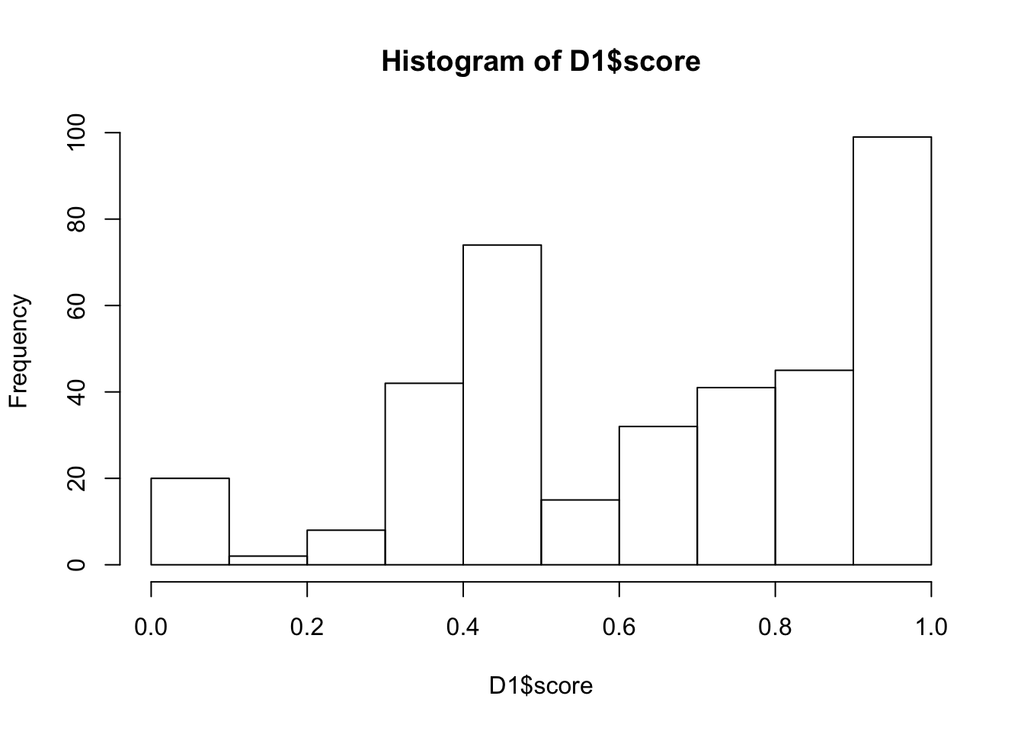

```r
hist(D1$score)
```

# Create a categorical outcome variable based on student score to advise the teacher using an “ifelse” statement

```r
D1$advice <- ifelse(D1$score < 0.4, "1", ifelse(D1$score < 0.8, "2", "3"))
# 1 - "teacher should intervene", 2 - "teacher should monitor student progress" and 3 - "no action"
```

# Build a decision tree that predicts “advice” based on how many problems students have answered before, the percentage of those problems they got correct and how many hints they required

```r
D1$advice <- as.factor(D1$advice)

score_ctree <- ctree(advice ~ prior_prob_count + prior_percent_correct + hints, data=D1)
```

# Plot tree

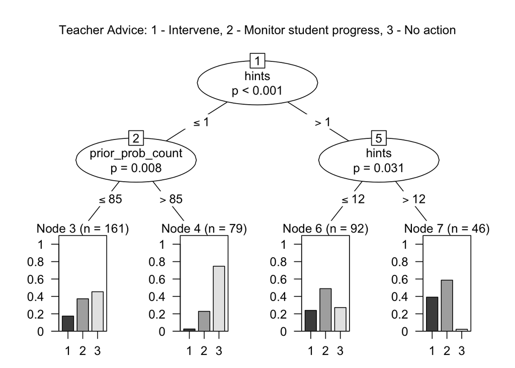

```r
plot(score_ctree, main = "Teacher Advice: 1 - Intervene, 2 - Monitor student progress, 3 - No action")
```

Please interpret the tree, which two behaviors do you think the teacher should most closely pay attention to?

### The teacher should most closely pay attention to students how have required more than 12 hints, or students who have have answered less than 85 questions before even though they didn’t requre any hints.

# Test Tree

Upload the data “intelligent_tutor_new.csv”. This is a data set of a differnt sample of students doing the same problems in the same system. We can use the tree we built for the previous data set to try to predict the “advice” we should give the teacher about these new students.

```r
#Upload new data

D2 <- read.csv("intelligent_tutor_new.csv")

#Generate predicted advice using the predict() command for new students based on tree generated from old students

D2$prediction <- predict(score_ctree, D2)
```

## Part III

Compare the predicted advice with the actual advice that these students recieved. What is the difference between the observed and predicted results?

```r
D2$actual <- ifelse(D2$score < 0.4, "1", ifelse(D2$score < 0.8, "2", "3"))
table(D2$prediction, D2$actual)
```

```
##
##       3
##   1   0
##   2  70
##   3 130
```

```r
mean(ifelse(D2$prediction == "3", 1, 0))
```

```
## [1] 0.65
```

```r
# -OR-
# sum(D2$prediction == "3")/length(D2$prediction)
```

### Since all the students scored 1 in this data set, the actual advice that these students recieved is “no action”. However, 130 of them fall into this category in the predicted results while 70 of them are in the “monitor student progress” group. Thus the accuracy of the decision tree is 0.65 in predicting the advice we should give the teacher about these new students.

### To Submit Your Assignment

Please submit your assignment by first “knitting” your RMarkdown document into an html file and then commit, push and pull request both the RMarkdown file and the html file.